# Practical Machine Learning Course Project

Nikhil Dubey

22/10/2020

##Introduction

Using devices such as Jawbone Up, Nike FuelBand and Fitbit, it is now possible to obtain a vast amount of personal activity data relatively cheaply. These types of devices are part of quantified self-movement — a community of enthusiasts who take measurements about themselves frequently to enhance their wellbeing, to find trends in their behaviour, or because they are tech geeks. One thing people do routinely is measure how much of a single task they do, but they rarely measure how well they do it.

The purpose of this project would be to use data from accelerometers on the belt, forearm, arm, and dumbell of 6 participants. They were asked to perform barbell lifts correctly and incorrectly in 5 different ways.

##Question

According to the aforementioned report, "Six young health participants were asked to perform a sequence of 10 replicas of the Unilateral Dumbbell Biceps Curl in five different ways: precisely in accordance with the criteria (Class A), by throwing the elbows at the front (Class B), by raising the halfway dumbbell (Class C), by lowering the halfway dumbbell (Class D) and by throwing the hips at the front. Class A refers to the execution of the exercise, while the other four sections correspond to typical errors. Our goal is to anticipate the way they did the exercise.

##Objective of assignment

1. Predicting the way the participants did the exercise. Please refer to the “class” variable in the training package. All other variables may be used as predictors.
2. Show how the model was developed, cross validation performed, and the expectation of the error of the sample and the reasons for the choices made.
3. Using the predictive model to forecast 20 separate test cases.

### Retrive and cleaning Data

This original source is the data for this project: http:/groupware.les.inf.puc-rio.br / har.

```r
library(data.table) #loading of the downloaded package data.table
library(mlbench) #loading of the downloaded package mlbench
library(caret) #loading of the downloaded package caret
library(klaR) #loading of the downloaded package klaR
library(randomForest) #loading of the downloaded package randomForest
library(rattle) #loading of the downloaded package rattle
```

```r
library(rpart) #loading of the downloaded package rpart
library(rpart.plot) #loading of the downloaded package rpart.plot
```

The training data for this project are available here: https://d396qusza40orc.cloudfront.net/predmachlearn/pml-training.csv

The test data are available here: https://d396qusza40orc.cloudfront.net/predmachlearn/pml-testing.csv

##Preparation of Datasets

```r
Training_Data <- fread("https://d396qusza40orc.cloudfront.net/predmachlearn/pml-training.csv", header=T, na.strings=c("NA","#DIV/0!","")) #creating variable for storing Traning Data
Testing_Data <- fread("http://d396qusza40orc.cloudfront.net/predmachlearn/pml-testing.csv", header=T, na.strings=c("NA","#DIV/0!","")) #creating variable for storing testing data
dim(Training_Data)
```

```
## [1] 19622   160
```

```r
dim(Testing_Data)
```

```
## [1]  20 160
```

“Now, we use the” Summary(Training_Data) “and” str(Training_Data) “commands to look at the data and, as we have 160 columns, we extract the names of the columns. We don’t include the outputs of”summary" and “str” as these commands retrieve a lot of rows, but we think it’s useful to know a list of names.

```r
names(Training_Data)
```

```
##   [1] "V1"                       "user_name"
##   [3] "raw_timestamp_part_1"     "raw_timestamp_part_2"
##   [5] "cvtd_timestamp"           "new_window"
##   [7] "num_window"               "roll_belt"
##   [9] "pitch_belt"               "yaw_belt"
##  [11] "total_accel_belt"         "kurtosis_roll_belt"
##  [13] "kurtosis_picth_belt"      "kurtosis_yaw_belt"
##  [15] "skewness_roll_belt"       "skewness_roll_belt.1"
##  [17] "skewness_yaw_belt"        "max_roll_belt"
##  [19] "max_picth_belt"           "max_yaw_belt"
##  [21] "min_roll_belt"            "min_pitch_belt"
##  [23] "min_yaw_belt"             "amplitude_roll_belt"
##  [25] "amplitude_pitch_belt"     "amplitude_yaw_belt"
##  [27] "var_total_accel_belt"     "avg_roll_belt"
##  [29] "stddev_roll_belt"         "var_roll_belt"
```

[output cut: 65 more lines]

Thus, we have many columns with “NA” values, and several columns also contain steps that are not relevant to us at this time (we want belt, arm and forearm variables). The next step, then, is to create a subset of data with parameters that are of interest to me and add the “result” column. The first thing to do would be to use “sapply” on the TrainingData and delete all NA or null variables, and then use the list to subset the main data set.

```r
List_Na <- sapply(Training_Data, function (x) any(is.na(x)))
newTraining_Data <- subset(Training_Data, select=c("classe", names(List_Na)[!List_Na & grepl("belt|[^(fore)]arm|dumbbell|forearm", names(List_Na))]))
```

Then we’ll have to convert the class to the Factor data type, so that the caret produces a classification rather than a regression model.

```r
newTraining_Data <- newTraining_Data[, classe := factor(newTraining_Data[, classe])]
newTraining_Data[, .N, classe]
```

```
##    classe    N
## 1:      A 5580
## 2:      B 3797
## 3:      C 3422
## 4:      D 3216
## 5:      E 3607
```

Lastly, we would split the training data data into two batches, 60 percent training data and 40 percent test data. 60 percent of the training data set as training and the rest for validation are divided. Once the best model is found, the original research data set will be checked.

```r
inn_Train <- createDataPartition(newTraining_Data$classe, p=0.6, list=FALSE)
Training_data <- newTraining_Data[inn_Train, ]
Testing_data <- newTraining_Data[-inn_Train, ]
```

Then we search whether there are near-zero variance predictors in the batch.

```r
nzv <- nearZeroVar(Training_data, saveMetrics=TRUE)
nzv
```

```
##                      freqRatio percentUnique zeroVar   nzv
## classe                1.469065    0.04245924   FALSE FALSE
## roll_belt             1.141243    8.73811141   FALSE FALSE
## pitch_belt            1.081081   13.83322011   FALSE FALSE
## yaw_belt              1.009585   14.61447011   FALSE FALSE
## total_accel_belt      1.068583    0.23777174   FALSE FALSE
## gyros_belt_x          1.046061    1.08695652   FALSE FALSE
## gyros_belt_y          1.135518    0.53498641   FALSE FALSE
## gyros_belt_z          1.089184    1.35869565   FALSE FALSE
## accel_belt_x          1.036017    1.34171196   FALSE FALSE
## accel_belt_y          1.143017    1.14639946   FALSE FALSE
## accel_belt_z          1.040076    2.42866848   FALSE FALSE
## magnet_belt_x         1.044843    2.46263587   FALSE FALSE
## magnet_belt_y         1.063291    2.40319293   FALSE FALSE
## magnet_belt_z         1.010870    3.64300272   FALSE FALSE
## roll_arm             51.743590   19.29347826   FALSE FALSE
## pitch_arm            87.782609   22.60529891   FALSE FALSE
## yaw_arm              27.643836   21.42493207   FALSE FALSE
## total_accel_arm       1.026071    0.56046196   FALSE FALSE
## gyros_arm_x           1.025806    5.28192935   FALSE FALSE
## gyros_arm_y           1.491803    3.02309783   FALSE FALSE
## gyros_arm_z           1.117264    1.95312500   FALSE FALSE
## accel_arm_x           1.087379    6.36888587   FALSE FALSE
## accel_arm_y           1.166667    4.46671196   FALSE FALSE
## accel_arm_z           1.024390    6.40285326   FALSE FALSE
## magnet_arm_x          1.036364   11.10733696   FALSE FALSE
## magnet_arm_y          1.084746    7.20108696   FALSE FALSE
## magnet_arm_z          1.014925   10.60631793   FALSE FALSE
## roll_dumbbell         1.048780   87.38111413   FALSE FALSE
## pitch_dumbbell        2.378049   85.41949728   FALSE FALSE
## yaw_dumbbell          1.093333   87.06691576   FALSE FALSE
## total_accel_dumbbell  1.027316    0.35665761   FALSE FALSE
## gyros_dumbbell_x      1.028011    1.91066576   FALSE FALSE
## gyros_dumbbell_y      1.254237    2.24184783   FALSE FALSE
## gyros_dumbbell_z      1.054598    1.64741848   FALSE FALSE
## accel_dumbbell_x      1.044118    3.39673913   FALSE FALSE
## accel_dumbbell_y      1.039474    3.81283967   FALSE FALSE
## accel_dumbbell_z      1.174825    3.34578804   FALSE FALSE
## magnet_dumbbell_x     1.110000    8.65319293   FALSE FALSE
## magnet_dumbbell_y     1.194175    6.87839674   FALSE FALSE
## magnet_dumbbell_z     1.034783    5.53668478   FALSE FALSE
## roll_forearm         11.179612   15.18342391   FALSE FALSE
## pitch_forearm        62.189189   20.75407609   FALSE FALSE
## yaw_forearm          15.653061   14.01154891   FALSE FALSE
## total_accel_forearm   1.124493    0.56895380   FALSE FALSE
## gyros_forearm_x       1.056075    2.30978261   FALSE FALSE
## gyros_forearm_y       1.083721    6.08016304   FALSE FALSE
## gyros_forearm_z       1.180769    2.38620924   FALSE FALSE
## accel_forearm_x       1.000000    6.59816576   FALSE FALSE
## accel_forearm_y       1.100000    8.18614130   FALSE FALSE
## accel_forearm_z       1.044444    4.67051630   FALSE FALSE
## magnet_forearm_x      1.125000   12.10088315   FALSE FALSE
## magnet_forearm_y      1.137255   15.30230978   FALSE FALSE
## magnet_forearm_z      1.184211   13.42561141   FALSE FALSE
```

We don’t have any predictors with a near-zero variance so we can continue with the construction of our model.

##Building Model

To suit the model to the data, we use the “train” function and the partial least square discriminant analysis (PLSDA) model to start.

```r
set.seed(12345)
ctrl <- trainControl(method = "repeatedcv", repeats = 3, classProbs = TRUE, summaryFunction = defaultSummary)
plsFit <- train(classe ~ ., data = Training_data, method = "pls", tuneLength = 15, trControl = ctrl, metric = "ROC", preProc = c("center","scale"))
```

[output not shown]

[output cut: 110 more lines]

[output not shown]

```r
plsFit
```

```
## Partial Least Squares
##
## 11776 samples
##    52 predictor
##     5 classes: 'A', 'B', 'C', 'D', 'E'
##
## Pre-processing: centered (52), scaled (52)
## Resampling: Cross-Validated (10 fold, repeated 3 times)
## Summary of sample sizes: 10598, 10600, 10598, 10600, 10598, 10598, ...
## Resampling results across tuning parameters:
##
##   ncomp  Accuracy   Kappa
##    1     0.3274456  0.1093860
##    2     0.3333344  0.1217409
##    3     0.3683463  0.1788879
##    4     0.4502090  0.2895857
##    5     0.4817720  0.3324271
##    6     0.5029451  0.3607968
##    7     0.5115236  0.3738145
##    8     0.5433368  0.4143092
##    9     0.5517995  0.4257208
##   10     0.5742191  0.4550270
##   11     0.5815223  0.4645391
##   12     0.5883728  0.4737547
##   13     0.5937508  0.4809542
##   14     0.6008829  0.4903195
##   15     0.6078462  0.4992089
##
## Accuracy was used to select the optimal model using the largest value.
## The final value used for the model was ncomp = 15.
```

The grid of results for this output is the average re-sampled estimates of efficiency. We use “predict” on our test data to implement the model.

```r
plsClass <- predict(plsFit, newdata = Testing_data)
str(plsClass)
```

```
##  Factor w/ 5 levels "A","B","C","D",..: 1 1 1 1 1 1 1 1 1 1 ...
```

We can also calculate this using the option type = “prob” to calculate the probabilities of the model class.

```r
plsProb <- predict(plsFit, newdata = Testing_data, type = "prob")
head(plsProb)
```

```
##           A         B         C         D         E
## 1 0.4252024 0.1270404 0.1541685 0.1337929 0.1597958
## 2 0.4221778 0.1297829 0.1561550 0.1337607 0.1581235
## 3 0.4171429 0.1301361 0.1563561 0.1338380 0.1625269
## 4 0.4267709 0.1280761 0.1539298 0.1327697 0.1584535
## 5 0.4302481 0.1266535 0.1529492 0.1327946 0.1573546
## 6 0.4192512 0.1274515 0.1544937 0.1341207 0.1646830
```

#We use a plot to display the result in the best manner.

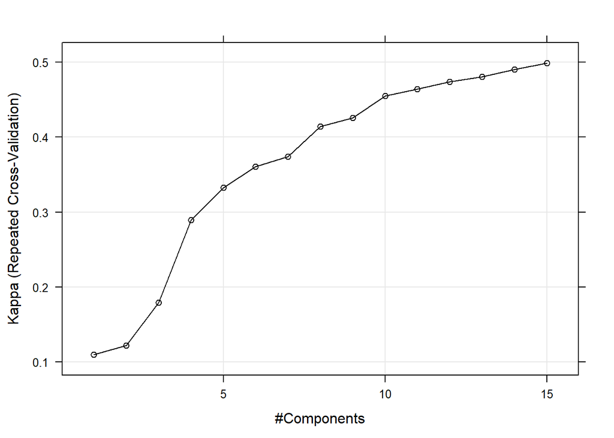

```r
trellis.par.set(caretTheme())
plot(plsFit, metric = "Kappa")
```

#We can also apply another model like the “regularized discriminant analysis” model

```r
set.seed(123)
rdaFit <- train(classe ~ ., data = Training_data, method = "rda", tuneGrid = data.frame(gamma = (0:4)/4, lambda = 3/4), trControl = ctrl, metric = "ROC")
rdaFit
```

```
## Regularized Discriminant Analysis
##
## 11776 samples
##    52 predictor
##     5 classes: 'A', 'B', 'C', 'D', 'E'
##
## No pre-processing
## Resampling: Cross-Validated (10 fold, repeated 3 times)
## Summary of sample sizes: 10599, 10597, 10599, 10597, 10598, 10600, ...
## Resampling results across tuning parameters:
##
##   gamma  Accuracy   Kappa
##   0.00   0.8241044  0.7783361
##   0.25   0.5887671  0.4814576
##   0.50   0.5223904  0.3966449
##   0.75   0.4738734  0.3341948
##   1.00   0.3990876  0.2353835
##
## Tuning parameter 'lambda' was held constant at a value of 0.75
## Accuracy was used to select the optimal model using the largest value.
## The final values used for the model were gamma = 0 and lambda = 0.75.
```

```r
rdaClasses <- predict(rdaFit, newdata = Testing_data)
confusionMatrix(rdaClasses, Testing_data$classe)
```

```
## Confusion Matrix and Statistics
##
##           Reference
## Prediction    A    B    C    D    E
##          A 1917  137   15    1   17
##          B   32 1103   82    7   86
##          C  172  219 1250  225   84
##          D  103   43   17 1043   75
##          E    8   16    4   10 1180
##
## Overall Statistics
##
##                Accuracy : 0.8276
##                  95% CI : (0.819, 0.8359)
##     No Information Rate : 0.2845
##     P-Value [Acc > NIR] : < 2.2e-16
##
##                   Kappa : 0.7827
##
##  Mcnemar's Test P-Value : < 2.2e-16
##
## Statistics by Class:
##
##                      Class: A Class: B Class: C Class: D Class: E
## Sensitivity            0.8589   0.7266   0.9137   0.8110   0.8183
## Specificity            0.9697   0.9673   0.8919   0.9637   0.9941
## Pos Pred Value         0.9185   0.8420   0.6410   0.8142   0.9688
## Neg Pred Value         0.9453   0.9365   0.9800   0.9630   0.9605
## Prevalence             0.2845   0.1935   0.1744   0.1639   0.1838
## Detection Rate         0.2443   0.1406   0.1593   0.1329   0.1504
## Detection Prevalence   0.2660   0.1670   0.2485   0.1633   0.1552
## Balanced Accuracy      0.9143   0.8470   0.9028   0.8874   0.9062
```

#and see how these two models (pls, rda) distinguish in terms of their resampling results.

```r
resamps <- resamples(list(pls = plsFit, rda = rdaFit))
summary(resamps)
```

```
##
## Call:
## summary.resamples(object = resamps)
##
## Models: pls, rda
## Number of resamples: 30
##
## Accuracy
##          Min.   1st Qu.    Median      Mean   3rd Qu.      Max. NA's
## pls 0.5811385 0.6008486 0.6073854 0.6078462 0.6119850 0.6307301    0
## rda 0.8079864 0.8183362 0.8242783 0.8241044 0.8292268 0.8411215    0
##
## Kappa
##          Min.   1st Qu.    Median      Mean   3rd Qu.      Max. NA's
## pls 0.4647903 0.4897609 0.4977503 0.4992089 0.5048786 0.5279183    0
## rda 0.7577667 0.7711320 0.7787267 0.7783361 0.7846175 0.7994127    0
```

```r
diffs <- diff(resamps)
summary(diffs)
```

```
##
## Call:
## summary.diff.resamples(object = diffs)
##
## p-value adjustment: bonferroni
## Upper diagonal: estimates of the difference
## Lower diagonal: p-value for H0: difference = 0
##
## Accuracy
##     pls       rda
## pls           -0.2163
## rda < 2.2e-16
##
## Kappa
##     pls       rda
## pls           -0.2791
## rda < 2.2e-16
```

#And then a plot to visualise the result

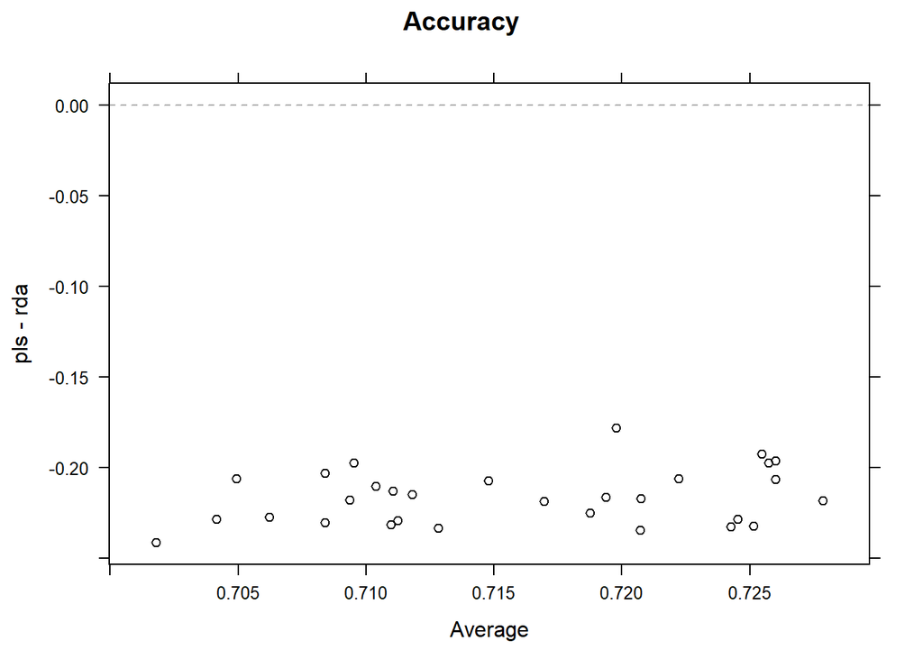

```r
xyplot(resamps, what = "BlandAltman")
```

#We can now also try the “Random Forest” model:

In random forests, to achieve an unbiased estimation of the test set error, there is no need for cross-validation or a separate test set. It is calculated internally, during the execution process. The testing of the model (Random Forest) is then carried out using the training data set.

```r
rfFit <- train(classe~., data=Training_data, method="rf",  tuneGrid=expand.grid(.mtry=sqrt(ncol(Training_data[,2:53]))), trControl=ctrl)
rfFit
```

```
## Random Forest
##
## 11776 samples
##    52 predictor
##     5 classes: 'A', 'B', 'C', 'D', 'E'
##
## No pre-processing
## Resampling: Cross-Validated (10 fold, repeated 3 times)
## Summary of sample sizes: 10599, 10598, 10598, 10600, 10598, 10597, ...
## Resampling results:
##
##   Accuracy   Kappa
##   0.9934897  0.9917645
##
## Tuning parameter 'mtry' was held constant at a value of 7.211103
```

```r
rfClasses <- predict(rfFit, newdata = Testing_data)
confusionMatrix(rfClasses, Testing_data$classe)
```

```
## Confusion Matrix and Statistics
##
##           Reference
## Prediction    A    B    C    D    E
##          A 2229    4    0    0    0
##          B    2 1512    4    0    0
##          C    0    2 1362   14    0
##          D    1    0    2 1271    8
##          E    0    0    0    1 1434
##
## Overall Statistics
##
##                Accuracy : 0.9952
##                  95% CI : (0.9934, 0.9966)
##     No Information Rate : 0.2845
##     P-Value [Acc > NIR] : < 2.2e-16
##
##                   Kappa : 0.9939
##
##  Mcnemar's Test P-Value : NA
##
## Statistics by Class:
##
##                      Class: A Class: B Class: C Class: D Class: E
## Sensitivity            0.9987   0.9960   0.9956   0.9883   0.9945
## Specificity            0.9993   0.9991   0.9975   0.9983   0.9998
## Pos Pred Value         0.9982   0.9960   0.9884   0.9914   0.9993
## Neg Pred Value         0.9995   0.9991   0.9991   0.9977   0.9988
## Prevalence             0.2845   0.1935   0.1744   0.1639   0.1838
## Detection Rate         0.2841   0.1927   0.1736   0.1620   0.1828
## Detection Prevalence   0.2846   0.1935   0.1756   0.1634   0.1829
## Balanced Accuracy      0.9990   0.9975   0.9966   0.9933   0.9971
```

```r
varImp(rfFit)
```

```
## rf variable importance
##
##   only 20 most important variables shown (out of 52)
##
##                      Overall
## roll_belt             100.00
## yaw_belt               69.21
## pitch_forearm          61.74
## magnet_dumbbell_z      59.30
## pitch_belt             53.58
## magnet_dumbbell_y      52.23
## roll_forearm           44.93
## magnet_dumbbell_x      34.83
## roll_dumbbell          30.94
## magnet_belt_z          30.94
## magnet_belt_y          30.57
## accel_dumbbell_y       30.27
## accel_belt_z           28.92
## accel_dumbbell_z       22.56
## accel_forearm_x        21.61
## roll_arm               21.08
## gyros_belt_z           18.44
## magnet_forearm_z       18.06
## total_accel_dumbbell   17.27
## gyros_dumbbell_y       16.86
```

```r
rfFit$finalModel
```

```
##
## Call:
##  randomForest(x = x, y = y, mtry = param$mtry)
##                Type of random forest: classification
##                      Number of trees: 500
## No. of variables tried at each split: 7
##
##         OOB estimate of  error rate: 0.57%
## Confusion matrix:
##      A    B    C    D    E class.error
## A 3344    3    0    0    1 0.001194743
## B   12 2260    7    0    0 0.008336990
## C    0   13 2041    0    0 0.006329114
## D    0    0   25 1904    1 0.013471503
## E    0    0    1    4 2160 0.002309469
```

## Conclusion:

#Now We can also try to use this model on our original testing batch of data and thus :

```r
Testing_Result <- predict(rfFit, newdata=Testing_Data)
Testing_Result
```

```
##  [1] B A B A A E D B A A B C B A E E A B B B
## Levels: A B C D E
```